# The State of Auckland’s Buses

A visual overview of the performance of buses in the Auckland transport network

Based on historical and real-time data, updated approximately every 30 minutes, obtained from Auckland Transport’s public GTFS API

# Real-time and historical bus data

- Using the public GTFS API provided by Auckland Transport, we obtain …
  - **GPS positions** (= position on a map), and
  - the **current delay** (= difference between scheduled and actual arrival time at last stop)

  … for all active buses in the network.
- Using data collected over the last 10 weeks, we can see if today is better or worse than usual

# How many buses?

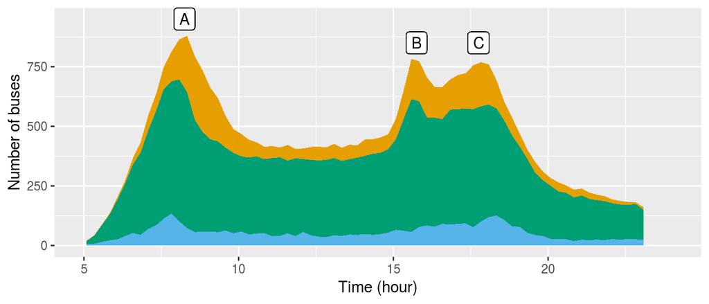

- Peak periods: **A** morning, **B** school, **C** evening
- The coloured areas represent the proportion  
  of buses that are, from top to bottom,
  - late by more than 5 minutes
  - on time (within 5 minutes of schedule)
  - more than 5 minutes early

# As of 2:30 pm today

- 328 of 421 buses were on time
- 32 were running more than 5 minutes late
- 61 were more than 5 minutes early

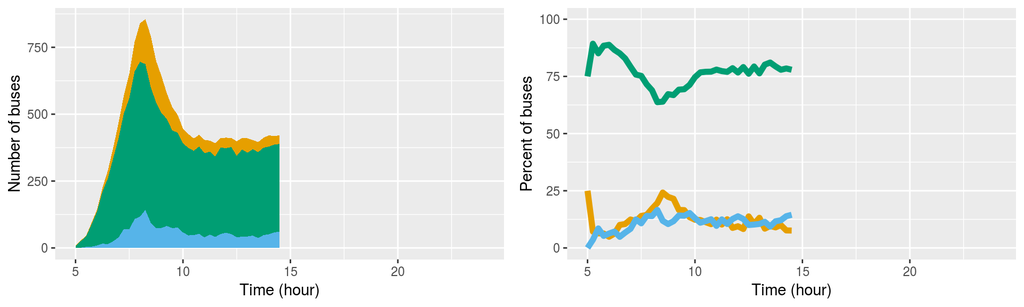

# Today vs. last 10 Mondays

- number and percentage of buses **early**, **ontime**, or **late**

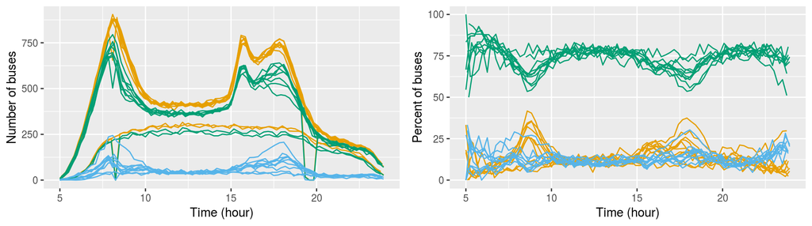

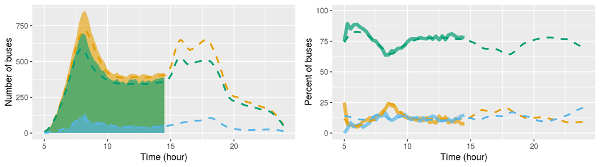

# This week vs. last 4 weeks

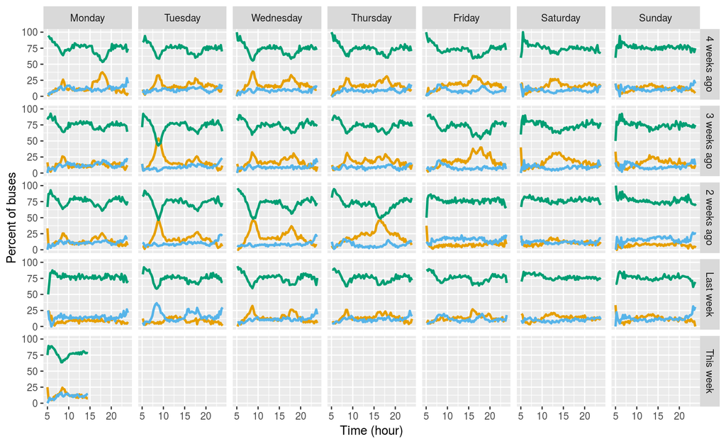

- percentage of buses **early**, **ontime**, or **late**

# So, just how late is late?

- Each dot represents one vehicle’s delay at 2:41 PM

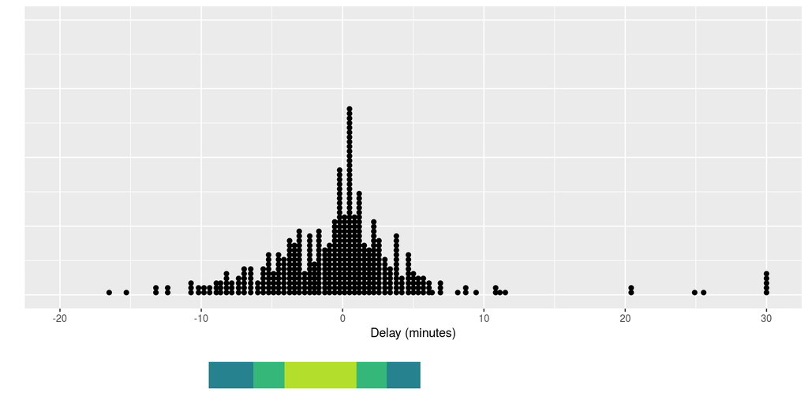

- the bar contains 90%, 75%, and 50% of buses

# Delays so far today

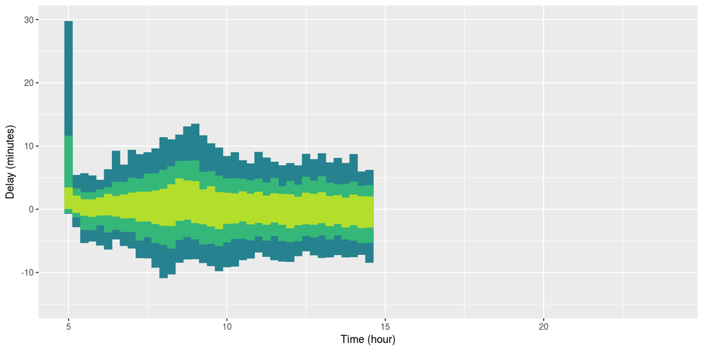

- rotating the bar from the previous graph, we see how the distribution of delays has changed today

# Today vs. last 10 Mondays

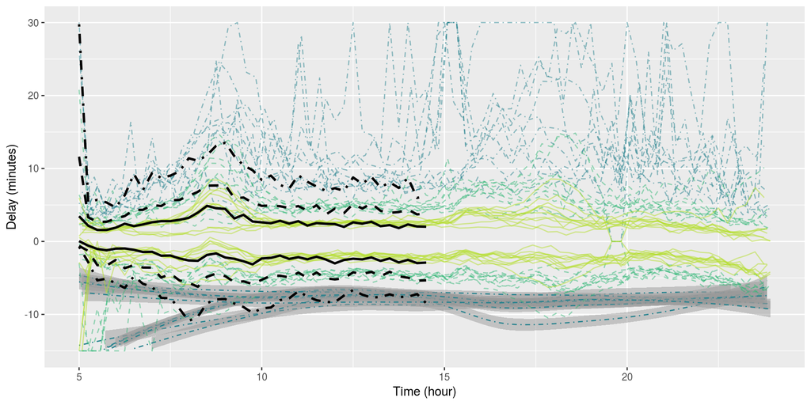

- coloured lines represent the 5% and 95%, 12.5% and 87.5%, and 25% and 75% quantiles of bus delays

# This week vs. last 4 weeks

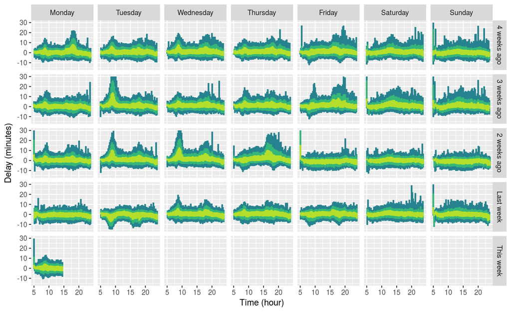

- the regions contain 90%, 75%, and 50% of buses